# House Selling Price

I have inspected and explored to see what variables seem to affect the Sale Price of a house with data of homes taken from Ames, Iowa.

**Contents:**

- Linear Model
- Graphical Presentation
- My Logic

### Linear Model

With Sale Price as our Response variable, we are using 2 quantitative X values: Above Ground Living Area and Total Square Footage. This is represented by the following model:

$$\overbrace{Y_i}^{Sale Price} = \beta_0 + \beta_1
\underbrace{X_{1i}}_{GrLivArea} + \beta2
\underbrace{X_{2i}}_{OverallQuality} + \beta3 \underbrace{X_{3i}}_{Rich
Neighborhoods} + \beta4 \underbrace{X_{4i}}_{TotalSF} + \beta5
\underbrace{X_{5i}}_{GarageCars} \\ + \beta6 X_{1i} X_{2i} + \beta7
X_{1i} X_{3i} + \beta8 X_{1i} X_{4i} + \epsilon_i \ where \ \epsilon \
\text{~} \ N(0, \sigma^2)$$

The values are explained in more depth:

```r
desc_txt <- tibble(
  Variable = c("GrLivArea", "OverallQuality", "Rich Neighborhoods", "TotalSF", "GarageCars"),
  description = c("Above Ground living Area Square Footage", "Rate of the overall material and finish of the house (1-10)", "Neighborhoods in a more well-to-do area of town", "Total Square Footage calculates total square footage of the home using 1st floor, 2nd floor, and Basement measurements", "Size of garage and its car capacity")
)

kable(desc_txt, caption="The variables used in the linear model and the context of each one.") %>%
  kable_styling(bootstrap_options = "striped")
```

The variables used in the linear model and the context of each one.

| Variable | description |
| --- | --- |
| GrLivArea | Above Ground living Area Square Footage |
| OverallQuality | Rate of the overall material and finish of the house (1-10) |
| Rich Neighborhoods | Neighborhoods in a more well-to-do area of town |
| TotalSF | Total Square Footage calculates total square footage of the home using 1st floor, 2nd floor, and Basement measurements |
| GarageCars | Size of garage and its car capacity |

### Estimated Model

$$\hat{Y} = 22930 - 63.66X_{1i} - 7895X_{2i} - 95680X_{3i} + 67.43X_{4i} +
14280X_{5i} + 18.32X_{1i}X_{2i} + 65.46X_{1i}X_{3i} -
0.01798X_{1i}X_{4i}$$

##### Technical Details

The linear regression is shown below:

```r
v_lm <- lm(SalePrice ~ GrLivArea + GrLivArea*OverallQual + GrLivArea*RichNbrhd + GrLivArea*TotalSF + GarageCars, data=mytrain)
summary(v_lm) %>%
  pander()
```

|  | Estimate | Std. Error | t value | Pr(>\|t\|) |
| --- | --- | --- | --- | --- |
| **(Intercept)** | 22934 | 15036 | 1.525 | 0.1275 |
| **GrLivArea** | -63.66 | 10.21 | -6.237 | 6.593e-10 |
| **OverallQual** | -7895 | 3575 | -2.208 | 0.02744 |
| **RichNbrhd** | -95678 | 14599 | -6.554 | 8.998e-11 |
| **TotalSF** | 67.43 | 4.853 | 13.89 | 3.205e-40 |
| **GarageCars** | 14279 | 1828 | 7.812 | 1.434e-14 |
| **GrLivArea:OverallQual** | 18.32 | 2.177 | 8.418 | 1.332e-16 |
| **GrLivArea:RichNbrhd** | 65.46 | 7.278 | 8.994 | 1.185e-18 |
| **GrLivArea:TotalSF** | -0.01798 | 0.002262 | -7.948 | 5.12e-15 |

Fitting linear model: SalePrice ~ GrLivArea + GrLivArea * OverallQual + GrLivArea * RichNbrhd + GrLivArea * TotalSF + GarageCars

| Observations | Residual Std. Error | $R^2$ | Adjusted $R^2$ |
| --- | --- | --- | --- |
| 1000 | 32252 | 0.8435 | 0.8422 |

Of course we must validate this and determine if this is a legitimate fit of the model.

```r
val_adj <- tibble(
  `R-Squared Metrics` = c("Original $R^2$", "Original Adjusted $R^2$", "Validation $R^2$", "Validation Adjusted $R^2$"),
  Value = c(summary(v_lm)$r.squared, summary(v_lm)$adj.r.squared, rst, rsta)
)

kable(val_adj, caption="$R^2$ metrics of the linear model which assess the fit on the model on the data.") %>%
  kable_styling(bootstrap_options = "striped")
```

$R^2$ metrics of the linear model which assess the fit on the model on the data.

| R-Squared Metrics | Value |
| --- | --- |
| Original $R^2$ | 0.8434746 |
| Original Adjusted $R^2$ | 0.8422110 |
| Validation $R^2$ | 0.8507320 |
| Validation Adjusted $R^2$ | 0.8480842 |

### Above Ground Square Footage

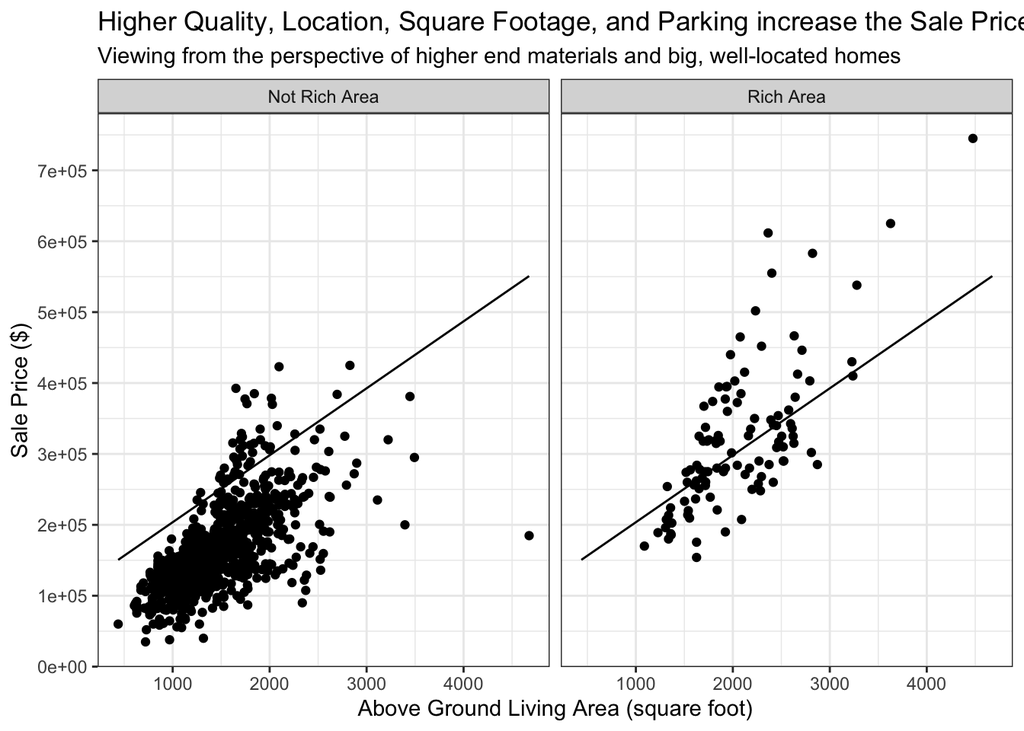

```r
ggplot(mytrain, aes(x=GrLivArea, y=SalePrice)) +
  geom_point() +
  facet_wrap(~RichNbrhd,
             labeller = labeller(`RichNbrhd` = c("0" = "Not Rich Area", "1" = "Rich Area"))) +
  stat_function(fun=function(GrLivArea, OverallQual=8, RichNbrhd = 1, TotalSF = 3000, GarageCars = 3) b[1] + b[2]*GrLivArea + b[3]*OverallQual + b[4]*RichNbrhd + b[5]*TotalSF + b[6]*GarageCars + b[7]*GrLivArea*OverallQual + b[8]*GrLivArea*RichNbrhd + b[9]*GrLivArea*TotalSF) +
  scale_y_continuous(breaks = seq(0, 700000, 100000)) +
  labs(title = "Higher Quality, Location, Square Footage, and Parking increase the Sale Price",
       subtitle = "Viewing from the perspective of higher end materials and big, well-located homes",
       x = "Above Ground Living Area (square foot)",
       y = "Sale Price ($)") +
  theme_bw()
```

## What Does This Mean?

There are a lot of moving parts in this linear model. Some of the estimated $\beta$ coefficients will affect the intercept of the line and some will affect the slope.

For this model we are using **GrLivArea** as our x-axis and **Sale Price** as our y-axis. However these aren’t the only quantitative values in the model. There is also **TotalSF**. This means we could have a 3D model with just those terms interacting with each other. If we add in another quantitative term it is 4D, and if we add in another it is 5D and so on. When we add a categorical variable, it doesn’t increase the dimension, but it does create multiple planes/lines that are scaled. Essentially when our categorical variable is at a fixed value, it will produce a plane/line. When you change that fixed value, the plane/line is changed.

When working with high dimensional spaces, we are not easily able to visualize it. We can only see things in 3D. If we use 3D as an example, then we can imagine a 3D object. Let’s use the example of a wedding cake. People can get pretty creative with their cakes. If they slice that cake in half, we can see the inside of the cake at the middle point. If we cut the half into half again, we now see the cake at the quarter mark of the whole cake. We see the 2D perspective of the cake.

So how can we “cut” my linear model and see it in a 2D perspective? We must fix the variables so we can slice the cake at the right spot and peer in. That is what the graph above represents.

```r
inter <- tibble(
  Variable = c("Above Ground Living Area (GrLivArea)", "Total Square Footage (TotalSF)", "Overall Quality (OverallQual)", "Rich Neighborhood (RichNbrhd)", "Number of Cars in Garage (GarageCars)"),
  `Fixed Value` = c("Nothing, we actually don't fix this value because it will be our x-axis.", "3,000 Square Feet", "8 ~ Very Good", "1 ~ Yes, it's a rich place", "3 car garage")
)

kable(inter, caption = "The Fixed Values for a more well-to-do home.  All of the chosen values are meant to reflect a larger home with more to offer.") %>%
  kable_styling(bootstrap_options = "striped")
```

The Fixed Values for a more well-to-do home. All of the chosen values are meant to reflect a larger home with more to offer.

| Variable | Fixed Value |
| --- | --- |
| Above Ground Living Area (GrLivArea) | Nothing, we actually don’t fix this value because it will be our x-axis. |
| Total Square Footage (TotalSF) | 3,000 Square Feet |
| Overall Quality (OverallQual) | 8 ~ Very Good |
| Rich Neighborhood (RichNbrhd) | 1 ~ Yes, it’s a rich place |
| Number of Cars in Garage (GarageCars) | 3 car garage |

#### Interpretation

So now to interpret the y-intercept and the slope for the main line.

```r
int <- b[1] + b[3]*8 + b[4] + b[5]*3000 + b[6]*3
slope <- b[2] + b[7]*8 + b[8] + b[9]*3000

line <- tibble(
  Coefficient = c("Y-Intercept", "Slope"),
  Value = c(int, slope)
)

kable(line, caption = "Values in $ that represent the model for Sale Price in Homes") %>%
  kable_styling(bootstrap_options = "striped")
```

Values in $ that represent the model for Sale Price in Homes

| Coefficient | Value |
| --- | --- |
| Y-Intercept | 109210.6866 |
| Slope | 94.4505 |

Beautiful! So in english, this is saying that with no Above Ground Living Space, but it still has square footage, good quality and location, and a 3 car garage, **our estimated value of the home is $109,210.69**. And for every square foot increase in Above Ground Living Space, we **increase the value of the home by $94.45**. Essentially we could say that with a good location, quality, 3-car garage, and 3,000sqft, a square foot of space equals $94.45.

### Logical Reasoning

To find this linear model, I first addressed the pairs plot. I looked for any variable that caused slope in the row with **Sale Price** as the y variable. I ran a simple linear regression with each variable to see how it interacted with Sale Price itself. I then started combining these variables since the data was showing that they were important. I decided that I would use **GrLivArea** and **TotalSF** as my quantitative variables with **Garage Cars**, a mutated variable **Rich Neighborhood**, and the **Overall Quality** as my categorical variables or on/off switches.

#### Sources

- Data Description Text from the zip file found on Kaggle helped me describe the different variables I was using
- GrokAI - for some styling help